# cm008 Exercises

## `mutate()`

Let’s get:

- GDP by multiplying GPD per capita with population, and
- GDP in billions, named (`gdpBill`), rounded to two decimals.

| country | continent | year | lifeExp | pop | gdpPercap | gdp | gdpBill |
| --- | --- | --- | --- | --- | --- | --- | --- |
| Afghanistan | Asia | 1952 | 28.80100 | 8425333 | 779.4453 | 6.567086e+09 | 6.57 |
| Afghanistan | Asia | 1957 | 30.33200 | 9240934 | 820.8530 | 7.585449e+09 | 7.59 |
| Afghanistan | Asia | 1962 | 31.99700 | 10267083 | 853.1007 | 8.758856e+09 | 8.76 |
| Afghanistan | Asia | 1967 | 34.02000 | 11537966 | 836.1971 | 9.648014e+09 | 9.65 |
| Afghanistan | Asia | 1972 | 36.08800 | 13079460 | 739.9811 | 9.678553e+09 | 9.68 |
| Afghanistan | Asia | 1977 | 38.43800 | 14880372 | 786.1134 | 1.169766e+10 | 11.70 |
| Afghanistan | Asia | 1982 | 39.85400 | 12881816 | 978.0114 | 1.259856e+10 | 12.60 |
| Afghanistan | Asia | 1987 | 40.82200 | 13867957 | 852.3959 | 1.182099e+10 | 11.82 |
| Afghanistan | Asia | 1992 | 41.67400 | 16317921 | 649.3414 | 1.059590e+10 | 10.60 |
| Afghanistan | Asia | 1997 | 41.76300 | 22227415 | 635.3414 | 1.412200e+10 | 14.12 |

[output cut: 990 more lines]

Notice the backwards compatibility! No need for loops!

Try the same thing, but with `transmute` (drops all other variables).

| gdp | gdpBill |
| --- | --- |
| 6.567086e+09 | 6.57 |
| 7.585449e+09 | 7.59 |
| 8.758856e+09 | 8.76 |
| 9.648014e+09 | 9.65 |
| 9.678553e+09 | 9.68 |
| 1.169766e+10 | 11.70 |
| 1.259856e+10 | 12.60 |
| 1.182099e+10 | 11.82 |
| 1.059590e+10 | 10.60 |
| 1.412200e+10 | 14.12 |

[output cut: 990 more lines]

The `if_else` function is useful for changing certain elements in a data frame.

Example: Suppose Canada’s 1952 life expectancy was mistakenly entered as 68.8 in the data frame, but is actually 70. Fix it using `if_else` and `mutate`.

| country | continent | year | lifeExp | pop | gdpPercap |
| --- | --- | --- | --- | --- | --- |
| Canada | Americas | 1952 | 70.000 | 14785584 | 11367.16 |
| Canada | Americas | 1957 | 69.960 | 17010154 | 12489.95 |
| Canada | Americas | 1962 | 71.300 | 18985849 | 13462.49 |
| Canada | Americas | 1967 | 72.130 | 20819767 | 16076.59 |
| Canada | Americas | 1972 | 72.880 | 22284500 | 18970.57 |
| Canada | Americas | 1977 | 74.210 | 23796400 | 22090.88 |
| Canada | Americas | 1982 | 75.760 | 25201900 | 22898.79 |
| Canada | Americas | 1987 | 76.860 | 26549700 | 26626.52 |
| Canada | Americas | 1992 | 77.950 | 28523502 | 26342.88 |
| Canada | Americas | 1997 | 78.610 | 30305843 | 28954.93 |

[output cut: 2 more lines]

Your turn: Make a new column called `cc` that pastes the country name followed by the continent, separated by a comma. (Hint: use the `paste` function with the `sep=", "` argument).

| country | continent | year | lifeExp | pop | gdpPercap | cc |
| --- | --- | --- | --- | --- | --- | --- |
| Afghanistan | Asia | 1952 | 28.80100 | 8425333 | 779.4453 | Afghanistan, Asia |
| Afghanistan | Asia | 1957 | 30.33200 | 9240934 | 820.8530 | Afghanistan, Asia |
| Afghanistan | Asia | 1962 | 31.99700 | 10267083 | 853.1007 | Afghanistan, Asia |
| Afghanistan | Asia | 1967 | 34.02000 | 11537966 | 836.1971 | Afghanistan, Asia |
| Afghanistan | Asia | 1972 | 36.08800 | 13079460 | 739.9811 | Afghanistan, Asia |
| Afghanistan | Asia | 1977 | 38.43800 | 14880372 | 786.1134 | Afghanistan, Asia |
| Afghanistan | Asia | 1982 | 39.85400 | 12881816 | 978.0114 | Afghanistan, Asia |
| Afghanistan | Asia | 1987 | 40.82200 | 13867957 | 852.3959 | Afghanistan, Asia |
| Afghanistan | Asia | 1992 | 41.67400 | 16317921 | 649.3414 | Afghanistan, Asia |
| Afghanistan | Asia | 1997 | 41.76300 | 22227415 | 635.3414 | Afghanistan, Asia |

[output cut: 990 more lines]

These functions we’ve seen are called **vectorized functions**.

## `summarize()` and `group_by()`

# Summarize function groups numbers and returns one number

Use `summarize()` to compute the mean and median life expectancy using all entries:

| mu | md |
| --- | --- |
| 59.47444 | 60.7125 |

Do the same thing, but try:

1. grouping by country
2. grouping by continent and country #Group by doesn’t change the dataframe, but adds another layer

| country | mu | md |
| --- | --- | --- |
| Afghanistan | 37.47883 | 39.14600 |
| Albania | 68.43292 | 69.67500 |
| Algeria | 59.03017 | 59.69100 |
| Angola | 37.88350 | 39.69450 |
| Argentina | 69.06042 | 69.21150 |
| Australia | 74.66292 | 74.11500 |
| Austria | 73.10325 | 72.67500 |
| Bahrain | 65.60567 | 67.32250 |
| Bangladesh | 49.83408 | 48.46600 |
| Belgium | 73.64175 | 73.36500 |

[output cut: 132 more lines]

| continent | country | mu | md |
| --- | --- | --- | --- |
| Africa | Algeria | 59.03017 | 59.69100 |
| Africa | Angola | 37.88350 | 39.69450 |
| Africa | Benin | 48.77992 | 50.04700 |
| Africa | Botswana | 54.59750 | 52.92700 |
| Africa | Burkina Faso | 44.69400 | 47.12950 |
| Africa | Burundi | 44.81733 | 45.03100 |
| Africa | Cameroon | 48.12850 | 49.60550 |
| Africa | Central African Republic | 43.86692 | 44.09900 |
| Africa | Chad | 46.77358 | 48.45000 |
| Africa | Comoros | 52.38175 | 51.93600 |

[output cut: 132 more lines]

- Notice the columns that are kept.
- Notice the grouping listed above the tibble, especially without a call after grouping.
- Notice the peeling of groups for each summarize.

Question: What if I wanted to keep the other numeric columns (gdpPercap, pop)? Can I? Would this even make sense? #There would be nothing left in the other columns; summarize function has compressed everything down, so it makes sense to get rid of them

For each continent: What is the smallest country-wide median GDP per capita? #Remember, every time you do summarize, it “peels back” the layers by one

| continent | min |
| --- | --- |
| Africa | 454.7593 |
| Americas | 1690.6724 |
| Asia | 378.0000 |
| Europe | 3194.3255 |
| Oceania | 16933.0641 |

Note that ggplot2’s grouping is different from dplyr’s! Try making a spaghetti plot of lifeExp over time for each coutry, by piping in a grouped data frame – it won’t work:

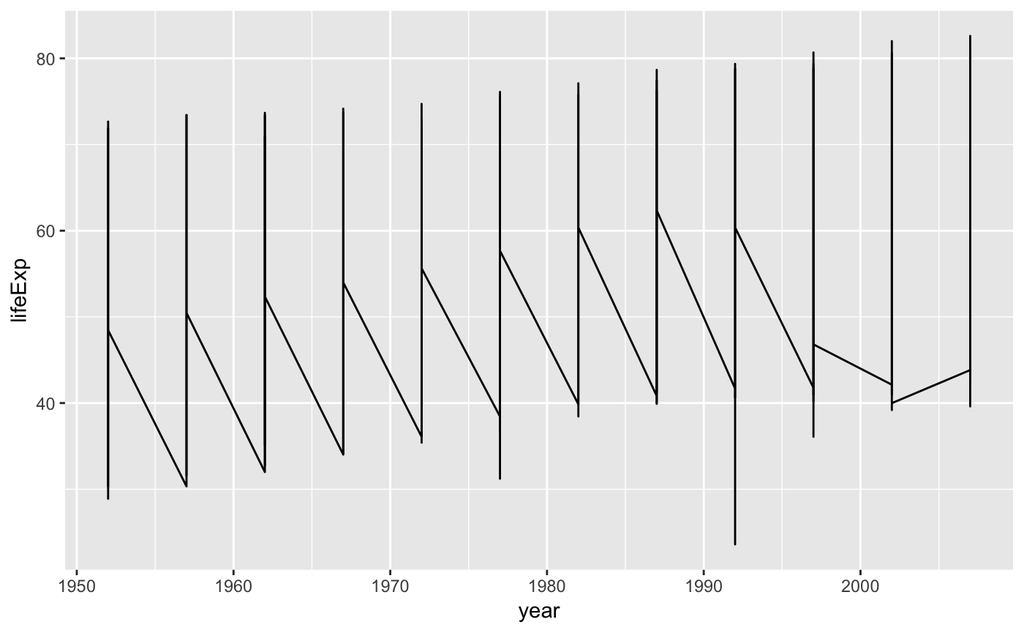

Your turn! For each continent, what is the median GDP per capita of countries with high (>60) life expectancy vs countries with low (<=60)? Sort this data frame by median GDP per capita.

| continent | lifeExp > 60 | md |
| --- | --- | --- |
| Asia | FALSE | 1030.592 |
| Africa | FALSE | 1071.332 |
| Europe | FALSE | 2383.578 |
| Americas | FALSE | 3080.333 |
| Africa | TRUE | 4441.931 |
| Asia | TRUE | 5249.803 |
| Americas | TRUE | 6678.334 |
| Europe | TRUE | 12671.575 |
| Oceania | TRUE | 17983.304 |

#If you want it to have a better labelling:

| continent | hvsl | md |
| --- | --- | --- |
| Asia | low | 1030.592 |
| Africa | low | 1071.332 |
| Europe | low | 2383.578 |
| Americas | low | 3080.333 |
| Africa | high | 4441.931 |
| Asia | high | 5249.803 |
| Americas | high | 6678.334 |
| Europe | high | 12671.575 |
| Oceania | high | 17983.304 |

#Another example

| continent | age | md |
| --- | --- | --- |
| Africa | High | 4441.931 |
| Africa | Low | 1071.332 |
| Americas | High | 6678.334 |
| Americas | Low | 3080.333 |
| Asia | High | 5249.803 |
| Asia | Low | 1030.592 |
| Europe | High | 12671.575 |
| Europe | Low | 2383.578 |
| Oceania | High | 17983.304 |

There are special functions to summarize by. Let’s see some of them:

- `n()`: Number of rows in the group.
- `n_distinct()`

| continent | num |
| --- | --- |
| Africa | 624 |
| Americas | 300 |
| Asia | 396 |
| Europe | 360 |
| Oceania | 24 |

Convenience functions:

- `tally()` (= `summarize(n = n())`)
- `count(...)` (= `group_by(...) %>% tally()`)

| continent | n |
| --- | --- |
| Africa | 624 |
| Americas | 300 |
| Asia | 396 |
| Europe | 360 |
| Oceania | 24 |

| continent | n |
| --- | --- |
| Africa | 624 |
| Americas | 300 |
| Asia | 396 |
| Europe | 360 |
| Oceania | 24 |

n_distinct: How many years of record does each country have?

count

## Function types

Let’s stop to identify some theory of function types, and the `dplyr` approach to them.

| Function type | Explanation | Examples | In `dplyr` |
| --- | --- | --- | --- |
| Vectorized functions | These take a vector, and operate on each component independently to return a vector of the same length. In other words, they work element-wise. | `cos`, `sin`, `log`, `exp`, `round` | `mutate` |
| Aggregate functions | These take a vector, and return a vector of length 1 | `mean`, `sd`, `length`, `typeof` | `summarize`, esp with `group_by`. |
| Window Functions | these take a vector, and return a vector of the same length that depends on the vector as a whole. | `lag`, `rank`, `cumsum` | `mutate`, esp with `group_by` |

For any generic output, we can use dplyr’s `do()` function – but that’s a topic for STAT 547.

## Grouped `mutate()`

Calculate the growth in population since the first year on record *for each country*. `first()` is useful.

| country | continent | year | lifeExp | pop | gdpPercap | growth |
| --- | --- | --- | --- | --- | --- | --- |
| Afghanistan | Asia | 1952 | 28.80100 | 8425333 | 779.4453 | 0 |
| Afghanistan | Asia | 1957 | 30.33200 | 9240934 | 820.8530 | 815601 |
| Afghanistan | Asia | 1962 | 31.99700 | 10267083 | 853.1007 | 1841750 |
| Afghanistan | Asia | 1967 | 34.02000 | 11537966 | 836.1971 | 3112633 |
| Afghanistan | Asia | 1972 | 36.08800 | 13079460 | 739.9811 | 4654127 |
| Afghanistan | Asia | 1977 | 38.43800 | 14880372 | 786.1134 | 6455039 |
| Afghanistan | Asia | 1982 | 39.85400 | 12881816 | 978.0114 | 4456483 |
| Afghanistan | Asia | 1987 | 40.82200 | 13867957 | 852.3959 | 5442624 |
| Afghanistan | Asia | 1992 | 41.67400 | 16317921 | 649.3414 | 7892588 |
| Afghanistan | Asia | 1997 | 41.76300 | 22227415 | 635.3414 | 13802082 |

[output cut: 990 more lines]

Notice that `dplyr` has retained the original grouping.

How about growth compared to `1972`?

| country | continent | year | lifeExp | pop | gdpPercap | growth |
| --- | --- | --- | --- | --- | --- | --- |
| Afghanistan | Asia | 1952 | 28.80100 | 8425333 | 779.4453 | -4654127 |
| Afghanistan | Asia | 1957 | 30.33200 | 9240934 | 820.8530 | -3838526 |
| Afghanistan | Asia | 1962 | 31.99700 | 10267083 | 853.1007 | -2812377 |
| Afghanistan | Asia | 1967 | 34.02000 | 11537966 | 836.1971 | -1541494 |
| Afghanistan | Asia | 1972 | 36.08800 | 13079460 | 739.9811 | 0 |
| Afghanistan | Asia | 1977 | 38.43800 | 14880372 | 786.1134 | 1800912 |
| Afghanistan | Asia | 1982 | 39.85400 | 12881816 | 978.0114 | -197644 |
| Afghanistan | Asia | 1987 | 40.82200 | 13867957 | 852.3959 | 788497 |
| Afghanistan | Asia | 1992 | 41.67400 | 16317921 | 649.3414 | 3238461 |
| Afghanistan | Asia | 1997 | 41.76300 | 22227415 | 635.3414 | 9147955 |

[output cut: 990 more lines]

Make a new variable `pop_last_time`, as the “lag-1” population – that is, the population from the previous entry of that country. Use the `lag` function.

| country | continent | year | lifeExp | pop | gdpPercap | change |
| --- | --- | --- | --- | --- | --- | --- |
| Afghanistan | Asia | 1952 | 28.80100 | 8425333 | 779.4453 | NA |
| Afghanistan | Asia | 1957 | 30.33200 | 9240934 | 820.8530 | 815601 |
| Afghanistan | Asia | 1962 | 31.99700 | 10267083 | 853.1007 | 1026149 |
| Afghanistan | Asia | 1967 | 34.02000 | 11537966 | 836.1971 | 1270883 |
| Afghanistan | Asia | 1972 | 36.08800 | 13079460 | 739.9811 | 1541494 |
| Afghanistan | Asia | 1977 | 38.43800 | 14880372 | 786.1134 | 1800912 |
| Afghanistan | Asia | 1982 | 39.85400 | 12881816 | 978.0114 | -1998556 |
| Afghanistan | Asia | 1987 | 40.82200 | 13867957 | 852.3959 | 986141 |
| Afghanistan | Asia | 1992 | 41.67400 | 16317921 | 649.3414 | 2449964 |
| Afghanistan | Asia | 1997 | 41.76300 | 22227415 | 635.3414 | 5909494 |

[output cut: 990 more lines]

Similar: `lead` function.

Notice the NA’s.

## Putting it all together

Your turn: Use what we learned to answer the following questions.

1. Determine the country that experienced the sharpest 5-year drop in life expectancy, in each continent.

| continent | min |
| --- | --- |
| Africa | -20.421 |
| Asia | -9.097 |
| Americas | -1.511 |
| Europe | -1.464 |
| Oceania | 0.170 |

2. Compute the relative gdp (NOT per capita!) of each country compared to Canada (= GDP of a country / GDP of Canada). #There are multiple ways to do this, including using Table Joins which we will learn next week! #The below is not the most sane way to do it, but it works to get an answer

```r
#Rep repeats a vector in a certain way
my_df %>%
  filter(country == "Canada")
```

[output not shown]

```
Error in eval(lhs, parent, parent) : object 'my_df' not found
```

Sanity check: are Canada’s numbers = 1? What is the spread of numbers like (should be small)?

## Summary of major one-table functions

- `select()`
- `filter()`
- `arrange()`
- `mutate()`
- `summarize()`

Together with `group_by()` and “twists” of the above.

## Practice Exercises

Practice these concepts in the following exercises. It might help you to first identify the type of function you are applying.

1. Convert the population to a number in billions.
2. Compute the change in population from 1962 to 1972 for each country.
3. Rank the continents by GDP per capita. You should have two columns: one with continent, and another with the ranking (1 through 5). **Hint**: use the `rank()` or `min_rank()` function.